# Introduction to Statistics for Parasitology

## 6.3 Nonlinear correlation

Many processes and relationships in biology are not linear, and sometimes we want to calculate correlation coefficients for those relationships. Consider the figure below. The left panel clearly shows some relationship between $X$ and $Y$, but it is not linear and using a linear correlation coefficient might miss something.

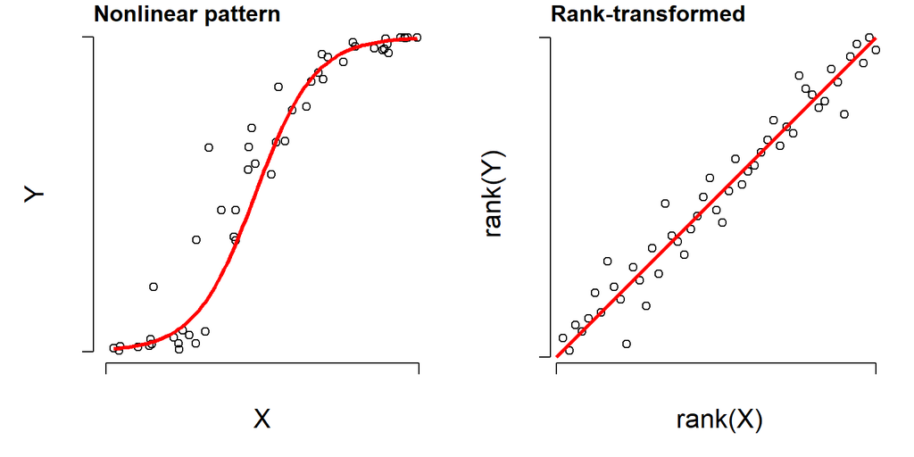

Figure 6: Left: illustration of a nonlinear correlation. Right: When values are rank-transformed, the nonlinear trend becomes linear.

However, if you **rank-transform** the data, the relationship turns into something more linear. A “rank-transform” assigns the smallest value value 0, the second smallest value to 1, and so on. Rank-transforming these data lets us calculate a nonparametric, nonlinear correlation. The nonparametric equivalent of Pearson’s *r* is **Spearman’s $\rho$** (“rho”). It can be obtained using code similar to that for linear correlation.

```r
# just the correlation
cor(iris$Petal.Length, iris$Sepal.Width, method="spearman")
```

```
[1] -0.3096351
```

```r
# significance test
cor.test(iris$Petal.Length, iris$Sepal.Width, method="spearman")
```

```
Warning in cor.test.default(iris$Petal.Length, iris$Sepal.Width, method =
"spearman"): Cannot compute exact p-value with ties
```

```
    Spearman's rank correlation rho

data:  iris$Petal.Length and iris$Sepal.Width
S = 736637, p-value = 0.0001154
alternative hypothesis: true rho is not equal to 0
sample estimates:
       rho
-0.3096351
```

When you run a nonlinear correlation test, you will often get the warning `Warning in cor.test.default ... : Cannot compute exact p-value with ties`. All this means is that some of the rankings are tied. This warning can be safely ignored.

# 7 Linear regression

Linear models describe relationships where a change in some response variable $Y$ is described by a unit change in a predictor $X$ multiplied by a constant called the **slope**. In other words, if $X$ increases by 1, then $Y$ increases by the slope. This change in $Y$ per unit change in $X$ is the same for all $X$, so a graph of the model is a straight line. This is why linear models are *called* linear models. The most important are the *t*-test and ANOVA (which we already covered), and linear regression and analysis of covariance (ANCOVA).

## 7.1 Lots of analyses are linear models in disguise (or can be)

Many models or curves that people fit to data, even some whose curves are nonlinear, are actually linear models in a statistical sense. A “linear model” does not mean that the graph must be a straight line. It means that the model is built by adding together predictor variables that are multiplied by constants (slopes), and these slopes are used only as multipliers of the predictor variables. For example, both $y=\beta_0+\beta_1x$ and $y=\beta_0+\beta_1x+\beta_2x^2+\beta_3x^3$ are linear models because the coefficients ($beta$ terms) are used only as multipliers of the predictor variables.

Other models that appear nonlinear can *become* linear models through transformation. For example, an exponential model $y=ae^{\beta_1x}$ is nonlinear, but log-transforming both sides yields the linear expression $\log\left(y\right)=log\left(a\right)+\beta_1x$. The section below illustrates a few of these “linear models in disguise” so you can recognize and apply these methods on your own data.

### 7.1.1 Ordinary linear models

The basic linear regression model is written as

$$y=\beta_0+\beta_1x$$

and is the same as the equation for a line that you learned in algebra: $y=mx+b$. Statisticians just use $\beta_0$ for the $Y$-intercept and $\beta_1$ for the slope instead of $b$ and $m$.

**Why it’s linear:** the parameters $\beta_0$ and $\beta_1$ appear only as multipliers or additive constants, and are combined by addition.

### 7.1.2 Polynomials

A polynomial is a function such as $Y=\beta_0+\beta_1X+\beta_2X^2+...+\beta_kX^k$, where $k$ is the **order** of the polynomial. A polynomial of order 2 is a quadratic equation. A polynomial of order 3 is a cubic, and so on. Polynomials have well-known shapes, such as the parabola of the quadratic function. Any polynomial with order $\ge2$ will not be a straight line.

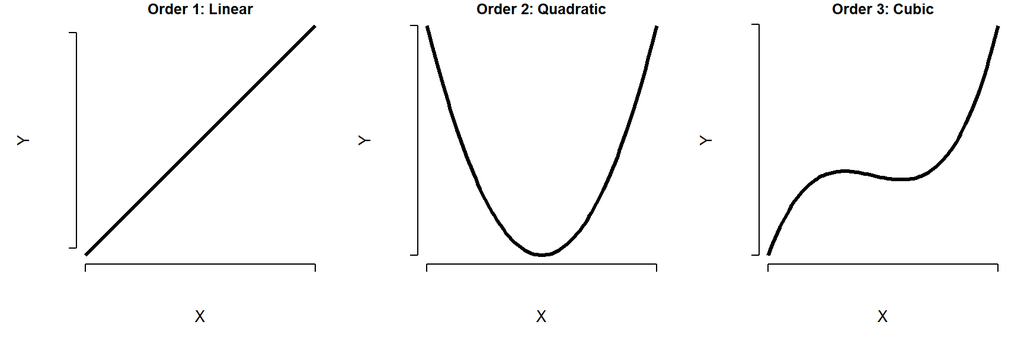

Figure 7: Curve shapes produced by polynomial equations of order 1, 2, and 3: linear, quadratic, and cubic, respectively.

**Why it’s linear:** although the graph may be curved, the parameters $\beta_0$, $\beta_1$, $\beta_2$, and so on appear only as multipliers on predictor variables, are combined by addition, and are not raised to powers, exponentiated, or use inside other functions.

### 7.1.3 Exponentials

The exponential function $y=ae^{bx}$ is ubiquitous in biology because it describes compounding growth (like compound interest). This function is not linear, but it can be turned into and analyzed as linear by log-transforming both sides.

[figure not shown]

Figure 8: Rick and Morty meme saying this sounds like linear with extra steps.

**Why it *can be* linear:** While the exponential function appears nonlinear, it can be made linear by log-transforming both sides:

$$log\left(y\right)=log\left(ae^{bx}\right)$$

$$log\left(y\right)=log\left(a\right)+log\left(e^{bx}\right)$$

and because $log\left(e^z\right)=z$:

$$log\left(y\right)=log\left(a\right)+bx$$

which is the form of a straight line with intercept $log\left(a\right)$ and slope $b$.

**Tip**

**Logarithm bases**

Mathematicians and statisticians almost always work with the **natural logarithm**, which uses Euler’s number $e$ ($\approx2.7182$) as its base. The natural logarithm can be written $log\left(x\right)$, $log_e\left(x\right)$, or $ln\left(x\right)$. Natural log is used because many [equations related to growth or change become easier](https://www.youtube.com/watch?v=m2MIpDrF7Es) when $e$ is the base. In this tutorial, and any math or statistics text, assume natural logarithm.

In contrast, scientists and engineers often use other bases, like $log_{10}$ or $log_2$, because these are more intuitive for humans. You can use whatever base you like so long as you are clear about what you did.

### 7.1.4 Power laws

**Power laws** of the form $Y=aX^b$ are also ubiquitous in biology, as they describe proportional growth. Power laws are similar to exponential functions, but with a key difference: in a power law, $X$ is in the base and is raised to a power, while in an exponential, $X$ is in the exponent of some other base.

**Why it *can be* linear:** Like an exponential, a power law can be linearized by taking the logarithm of both sides.

$$log\left(Y\right)=log\left(aX^b\right)$$

$$log\left(Y\right)=log\left(a\right)+b\times log\left(X\right)$$

In this form, the power law is linear with intercept $log\left(a\right)$ and slope $b$.

## 7.2 Linear regression

The linear regression model describes a pattern where the response variable $Y$ changes as a linear function of the predictor variable $X$. It looks like this:

$$Y=\beta_0+\beta_1X+\varepsilon$$

where $\beta_0$ is the $y$-intercept, $\beta_1$ is the slope (effect of a unit increase in $X$ on $Y$), and $\varepsilon$ is residual variation in $Y$ not explained by $X$–the spread of points above or below the line. In a linear model, residual variation follows a normal distribution with mean 0 and some unknown SD $\sigma_{\mathrm{res}}$. Each residual $\varepsilon_i$ follows the same distribution:

$$\varepsilon_i \sim \mathcal{N}\left(0,\sigma_{\mathrm{res}}\right)$$

where $\mathcal{N}$ signifies the normal distribution.

The R syntax for linear regression is basically the same as that for ANOVA and the *t*-test above, but this time the right hand side of the formula has a continuous predictor rather than a factor.

```r
# fit a linear regression model
mod5 <- lm(Petal.Length~Petal.Width, data=iris)
```

```r
# test for significance of terms
anova(mod5)
```

```
Analysis of Variance Table

Response: Petal.Length
             Df Sum Sq Mean Sq F value    Pr(>F)
Petal.Width   1 430.48  430.48  1882.5 < 2.2e-16 ***
Residuals   148  33.84    0.23
---
Signif. codes:  0 '***' 0.001 '**' 0.01 '*' 0.05 '.' 0.1 ' ' 1
```

```r
# see estimates of parameter coefficients
summary(mod5)
```

```
Call:
lm(formula = Petal.Length ~ Petal.Width, data = iris)

Residuals:
     Min       1Q   Median       3Q      Max
-1.33542 -0.30347 -0.02955  0.25776  1.39453

Coefficients:
            Estimate Std. Error t value Pr(>|t|)
(Intercept)  1.08356    0.07297   14.85   <2e-16 ***
Petal.Width  2.22994    0.05140   43.39   <2e-16 ***
---
Signif. codes:  0 '***' 0.001 '**' 0.01 '*' 0.05 '.' 0.1 ' ' 1

Residual standard error: 0.4782 on 148 degrees of freedom
Multiple R-squared:  0.9271,    Adjusted R-squared:  0.9266
F-statistic:  1882 on 1 and 148 DF,  p-value: < 2.2e-16
```

The `summary()` output tells you a lot about the regression: the coefficients (and their *p*-values), the omnibus ANOVA for the model (the *F* test at the bottom), and the coefficient of determination (Adjusted *R*-squared). Coefficients are identified as the y-intercept $\beta_0$ (`Intercept`) and by the variable names (e.g., the slope with respect to petal width is `Petal.Width`). Each coefficient is presented as its estimate and SE (e.g., the intercept is `1.08 ± 0.07`). The test statistic *t* for each coefficient is the ratio of the estimate to the SE, and the *P*-value for *t* calculated from a *t*-distribution (much as in a *t*-test). The coefficient of determination $R^2$ is the proportion of variation in $Y$ explained by the model. In this case, about 93% of variation in Petal.Length is explained by Petal.Width.

When you present a linear regression, you should present the parameters, their SE, test statistics, and *p*-values in a table. The omnibus $F$ test and $R^2$ can be reported in Results text. Finally, you should present the data as a scatterplot, with the predicted values as a trendline and the 95% CI of that trendline if feasible. Here is how to do that for the model above:

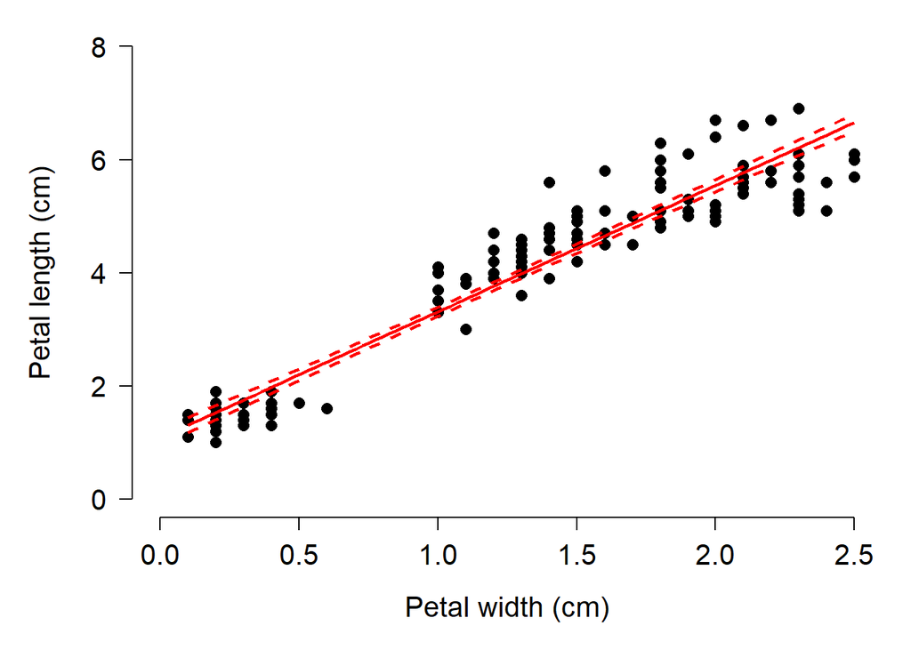

Figure 9: Data plotted with the trendline (solid) and its 95% confidence interval (dashed).

```r
# generate x values over which to draw trendline
n <- 100
px <- seq(min(iris$Petal.Width), max(iris$Petal.Width), length=n)

# put in a data frame with same variable names as in the model
prx <- data.frame(Petal.Width=px)

# calculate predicted values and their SE
pred <- predict(mod5, newdata=prx, se.fit=TRUE)

# put predicted value and 95% confidence limits into data frame
# safest method is to draw quantiles from normal distribution
# defined by predicted value (pred$fit) and SEs (pred$se.fit)
prx$mn <- qnorm(0.5, mean=pred$fit, sd=pred$se.fit)
prx$lo <- qnorm(0.025, mean=pred$fit, sd=pred$se.fit)
prx$up <- qnorm(0.975, mean=pred$fit, sd=pred$se.fit)

# make the plot
## include some par options for a more professional figure
## see ?par for definitions
par(mfrow=c(1,1), mar=c(5.1, 5.1, 1.1, 1.1),
    lend=1, las=1, bty="n", cex.axis=1.3, cex.lab=1.3)
## make the base plot
plot(iris$Petal.Width, iris$Petal.Length, pch=16, cex=1.2,
     xlab="Petal width (cm)", ylab="Petal length (cm)",
     xlim=c(0, 2.5), ylim=c(0, 8))
## add trendline and 95% confidence limits as lines with points(...,type="l")
points(prx$Petal.Width, prx$lo, type="l", lwd=2, col="red", lty=2)
points(prx$Petal.Width, prx$up, type="l", lwd=2, col="red", lty=2)
points(prx$Petal.Width, prx$mn, type="l", lwd=2, col="red")
```

## 7.3 Multiple linear regression

Linear regression is easily extended to **multiple linear regression**, where there are >1 continuous predictors. Just as with ANOVA, additional predictor variables are added to the model formula using +.

```r
mod6 <- lm(Petal.Length~Petal.Width + Sepal.Width, data=iris)
summary(mod6)
```

```
Call:
lm(formula = Petal.Length ~ Petal.Width + Sepal.Width, data = iris)

Residuals:
     Min       1Q   Median       3Q      Max
-1.33753 -0.29251 -0.00989  0.21447  1.24707

Coefficients:
            Estimate Std. Error t value Pr(>|t|)
(Intercept)  2.25816    0.31352   7.203 2.84e-11 ***
Petal.Width  2.15561    0.05283  40.804  < 2e-16 ***
Sepal.Width -0.35503    0.09239  -3.843  0.00018 ***
---
Signif. codes:  0 '***' 0.001 '**' 0.01 '*' 0.05 '.' 0.1 ' ' 1

Residual standard error: 0.4574 on 147 degrees of freedom
Multiple R-squared:  0.9338,    Adjusted R-squared:  0.9329
F-statistic:  1036 on 2 and 147 DF,  p-value: < 2.2e-16
```

Adding predictors to a multiple regression model will almost always increase the model fit (e.g., proportion of variance explained, $R^2$), but this does not mean you should keep adding predictors. Multiple regression models are extremely vulnerable to **overfitting**, where random noise (i.e., residual variation) is modeled as if it was part of the deterministic part of the model. Multiple regression models are also highly vulnerable to **collinearity**, where the predictors are correlated with each other. When collinear predictors are included in a model, it is impossible for the model to unambiguously partition the sums of squares associated with each predictor.

## 7.4 Analysis of covariance (ANCOVA)

Sometimes biologists want to test for effects of one variable while controlling for another. For example, the slope between $Y$ and $X$ might differ between groups. Or, groups might differ only after accounting for some continuous covariate. Here are some specific examples:

- Herbivorous mammals tend to have longer intestines than carnivorous mammals, but only after accounting for the effect of body mass on intestine length. The researcher wants to see how groups differ, but needs to control for a continuous variable (body length) first.
- Humerus length and femur length both increase with body mass in birds, but humerus length increases faster than femur length (i.e., their slopes are different). The researcher wants to test for a difference in a continous relationship, but needs to control for a factor (which bone) first.

The method for both situations is called **analysis of covariance**, or **ANCOVA**. You can think of ANCOVA as combining linear regression and ANOVA. ANCOVA is especialy useful for studying **interactions**, where one variable changes the effect of another.

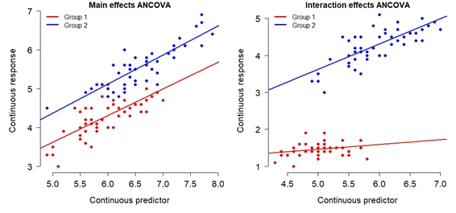

Figure 10: Illustration of ANCOVA without an interaction (different intercepts, same slope) and with an interaction (different intercepts and slopes.)

So that we really understand what an ANCOVA does, let’s simulate our own dataset where groups A and B have different slopes.

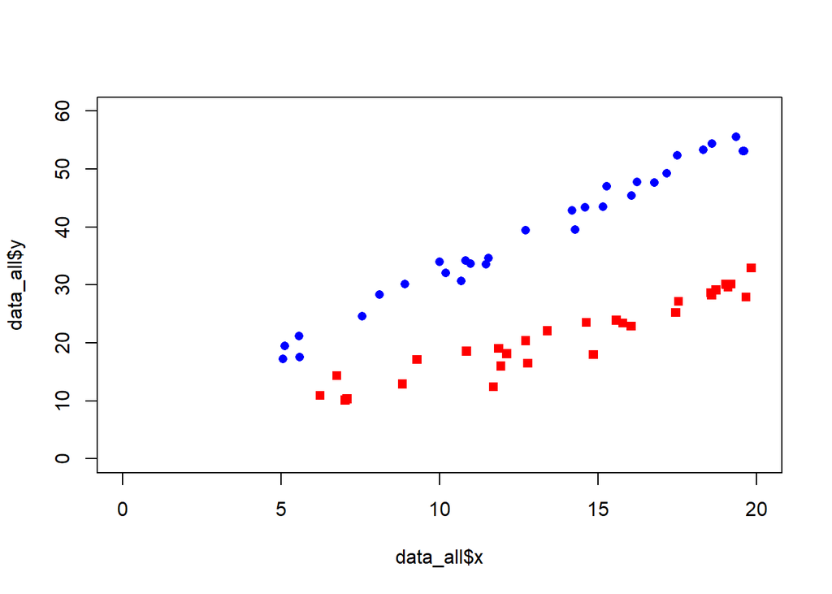

```r
# simulation parameters
set.seed(42)
n <- 30
beta0_a <- 2
beta0_b <- 6
beta1_a <- 1.4
beta1_b <- 2.5
sigma_res <- 2

# groups A and B start in separate data frames
data_a <- data.frame(group="A", col="red", pch=15, x=runif(n, 5, 20))
data_b <- data.frame(group="B", col="blue", pch=16, x=runif(n, 5, 20))

# add expected values
data_a$ey <- beta0_a + beta1_a * data_a$x
data_b$ey <- beta0_b + beta1_b * data_b$x

# combine to single data frame
data_all <- rbind(data_a, data_b)

# add residuals
data_all$y <- data_all$ey + rnorm(n*2, mean=0, sd=sigma_res)

# and make a plot to inspect our data
plot(data_all$x, data_all$y, col=data_all$col, pch=data_all$pch,
     xlim=c(0, 20), ylim=c(0, 60))
```

Now we can fit the ANCOVA and see the results.

```r
# fit the model. Notice the * to specify an interaction
mod7 <- lm(y~x*group, data=data_all)

# test significance of terms
anova(mod7)
```

```
Analysis of Variance Table

Response: y
          Df Sum Sq Mean Sq  F value    Pr(>F)
x          1 3507.2  3507.2 1012.289 < 2.2e-16 ***
group      1 5664.0  5664.0 1634.827 < 2.2e-16 ***
x:group    1  311.0   311.0   89.778 3.108e-13 ***
Residuals 56  194.0     3.5
---
Signif. codes:  0 '***' 0.001 '**' 0.01 '*' 0.05 '.' 0.1 ' ' 1
```

Now check the model parameters

```r
summary(mod7)
```

```
Call:
lm(formula = y ~ x * group, data = data_all)

Residuals:
    Min      1Q  Median      3Q     Max
-5.5122 -0.9491  0.4801  1.1691  3.8166

Coefficients:
            Estimate Std. Error t value Pr(>|t|)
(Intercept)  0.44990    1.17053   0.384 0.702170
x            1.49194    0.07883  18.925  < 2e-16 ***
groupB       5.62958    1.55677   3.616 0.000642 ***
x:groupB     1.03148    0.10886   9.475 3.11e-13 ***
---
Signif. codes:  0 '***' 0.001 '**' 0.01 '*' 0.05 '.' 0.1 ' ' 1

Residual standard error: 1.861 on 56 degrees of freedom
Multiple R-squared:  0.9799,    Adjusted R-squared:  0.9789
F-statistic: 912.3 on 3 and 56 DF,  p-value: < 2.2e-16
```

R treats group A as the control or **baseline** because it is alphabetically first. Any effect involving group B is relative to the effect in group A. Here:

- The intercept in group A is `(Intercept)`, 0.4499.
- The slope in group A is `x`, 1.4919.
- The intercept in group B is the group A intercept plus the effect of being in group B: $0.4499 + 5.6295=6.0794$.
- The slope in group B is the slope in group A plus the effect of being in group B on the slope: $1.4919 + 1.0314=2.5233$`

Making a plot with trendlines for an ANCOVA follows much the same procedure as we used to make the plot for linear regression, but, you have to take care to include each group.

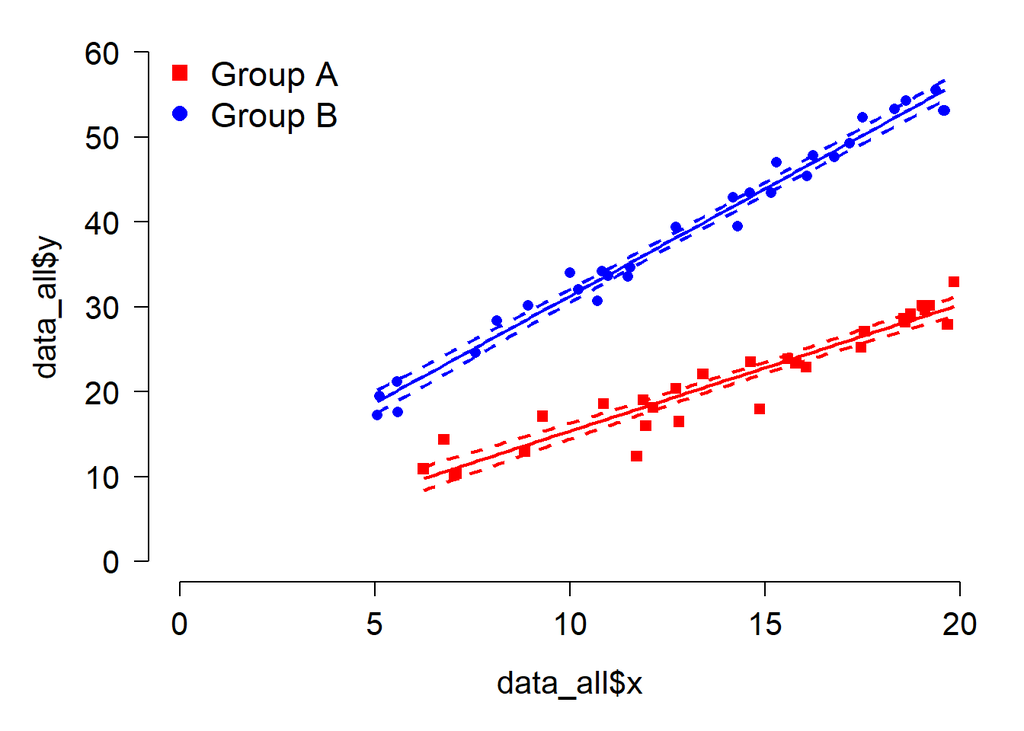

Figure 11: Plot of Y vs. X with groups A and B in the data, where the groups have different slopes. This illustrations ANCOVA with an interaction between X and group.

```r
# get x sequence within the x domain of each group
pxa <- seq(min(data_all$x[data_all$group=="A"]),
           max(data_all$x[data_all$group=="A"]),
           length=100)
pxb <- seq(min(data_all$x[data_all$group=="B"]),
           max(data_all$x[data_all$group=="B"]),
           length=100)
# put in data frames
prxa <- data.frame(group="A", x=pxa)
prxb <- data.frame(group="B", x=pxb)

# calculate predictions
preda <- predict(mod7, newdata=prxa, se.fit=TRUE)
predb <- predict(mod7, newdata=prxb, se.fit=TRUE)

# add to data frames
prxa$mn <- qnorm(0.5, preda$fit, preda$se.fit)
prxa$lo <- qnorm(0.025, preda$fit, preda$se.fit)
prxa$up <- qnorm(0.975, preda$fit, preda$se.fit)

prxb$mn <- qnorm(0.5, predb$fit, predb$se.fit)
prxb$lo <- qnorm(0.025, predb$fit, predb$se.fit)
prxb$up <- qnorm(0.975, predb$fit, predb$se.fit)

# make the plot
par(mar=c(5.1, 5.1, 1.1, 1.1), bty="n", las=1, lend=1,
    cex.axis=1.3, cex.lab=1.3)
plot(data_all$x, data_all$y, col=data_all$col, pch=data_all$pch,
     xlim=c(0, 20), ylim=c(0, 60))
points(prxa$x, prxa$mn, type="l", lwd=2, col="red")
points(prxa$x, prxa$lo, type="l", lwd=2, col="red", lty=2)
points(prxa$x, prxa$up, type="l", lwd=2, col="red", lty=2)
points(prxb$x, prxb$mn, type="l", lwd=2, col="blue")
points(prxb$x, prxb$lo, type="l", lwd=2, col="blue", lty=2)
points(prxb$x, prxb$up, type="l", lwd=2, col="blue", lty=2)
legend("topleft", legend=c("Group A", "Group B"),
       pch=c(15, 16), col=c("red", "blue"), cex=1.4,
       bty="n")
```

# 8 Generalized linear models

The **generalized linear model (GLM)** is a framework of related methods that generalize the linear model by relaxing two of the conditions in which linear models are used. In a GLM:

- The response variable can be modeled on a different scale than its original scale. The original scale of the data is related to the scale of the linear prediction by a **link function**.
- The values of the response variable can come from many different distributions, not just the normal distribution.

There are four GLMs that biologists commonly encounter. The first is linear regression, which we have already covered. Linear regression can be expressed as a GLM like this:

$$Y\sim \mathcal{N}\left(\mu, \sigma\right)$$
$$\mu=\eta$$

$$\eta=\beta_0+\beta_1X$$

The linear predictor, $\eta$ (“eta”) is a linear function of $X$. The expected value of Y, $\mu$, is equal to $\eta$. That is, $\mu$ is related to $\eta$ by the identity function. Finally, observed values in $Y$ are drawn from a normal distribution with mean $\mu$ and SD $\sigma$.

## 8.1 Models for counts: Poisson GLM

Another common GLM biologists encounter is the **Poisson GLM for count data**. Count data are exactly what they sound like: values that are counted and can only take on non-negative integer values. Because counts can only be non-negative integers, the normal distribution is not appropriate because it is supported on the entire real number line. Here is the Poisson GLM:

$$Y\sim \mathcal{Poisson}\left(\lambda\right)$$

$$log\left(\lambda\right)=\eta$$

$$\eta=\beta_0+\beta_1X$$

As with linear regression, the linear predictor $\eta$ is a linear function of $X$. However, $\eta$ is a logarithm of the expected value of $Y$, $\lambda$. So, the link function that relates the expected value $\lambda$ to the linear predictor scale expected value $\eta$ is the $log$ function. Finally, observed $Y$ values are drawn from a Poisson distribution with expected value (mean) $\lambda$. The single parameter $\lambda$ is also the variance ($\sigma^2$) of the distribution.

Let’s simulate some data and fit a Poisson GLM.

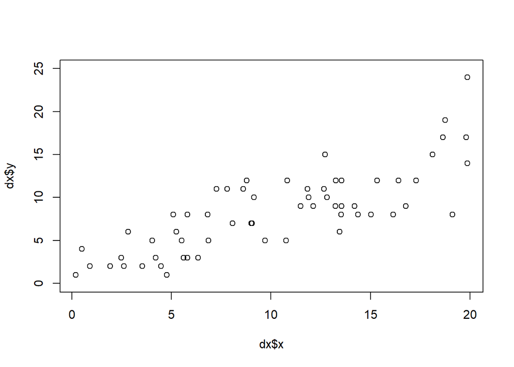

Figure 12: Plot of simulated count data, where $Y$ increases with $X$.

```r
# simulate some data
set.seed(321)
n <- 60
dx <- data.frame(x=runif(n, 0, 20))
beta0 <- 1.3
beta1 <- 0.65
dx$eta <- beta0 + beta1*dx$x
dx$y <- rpois(n, dx$eta)

# check the data
plot(dx$x, dx$y, ylim=c(0, 25))
```

Now fit the Poisson GLM. The omnibus test for most GLMs that aren’t also linear models (e.g., linear regression or ANCOVA) is a likelihood ratio test against a **null model**–a model with only the mean as a predictor.

```r
# fit the model
mod8 <- glm(y~x, data=dx, family=poisson(link="log"))

# fit a null model with no predictors, for comparison
mod8.null <- glm(y~1, data=dx, family=poisson(link="log"))

# Omnibus test: likelihood ratio test vs. null model
anova(mod8.null, mod8, test="Chisq")
```

```
Analysis of Deviance Table

Model 1: y ~ 1
Model 2: y ~ x
  Resid. Df Resid. Dev Df Deviance  Pr(>Chi)
1        59    161.939
2        58     61.671  1   100.27 < 2.2e-16 ***
---
Signif. codes:  0 '***' 0.001 '**' 0.01 '*' 0.05 '.' 0.1 ' ' 1
```

This would be reported as “a likelihood ratio test found the model significantly different than the null model ($\chi^2_1 = 100.27$, $p<0.001$.)

As usual, we can see the model parameters with `summary()`.

```r
summary(mod8)
```

```
Call:
glm(formula = y ~ x, family = poisson(link = "log"), data = dx)

Coefficients:
            Estimate Std. Error z value Pr(>|z|)
(Intercept) 1.180590   0.115666  10.207   <2e-16 ***
x           0.082894   0.008463   9.794   <2e-16 ***
---
Signif. codes:  0 '***' 0.001 '**' 0.01 '*' 0.05 '.' 0.1 ' ' 1

(Dispersion parameter for poisson family taken to be 1)

    Null deviance: 161.939  on 59  degrees of freedom
Residual deviance:  61.671  on 58  degrees of freedom
AIC: 293.45

Number of Fisher Scoring iterations: 4
```

You can then generate and draw a trendline much as we have before, with one wrinkle: calculate the expected values on the link scale, then exponentiate to get the values on the data scale. If you use `qpois()` to calculate expected values, you will get a step function rather than a smooth curve, because `qpois()` returns values from the Poisson distribution…which must be non-negative integers.

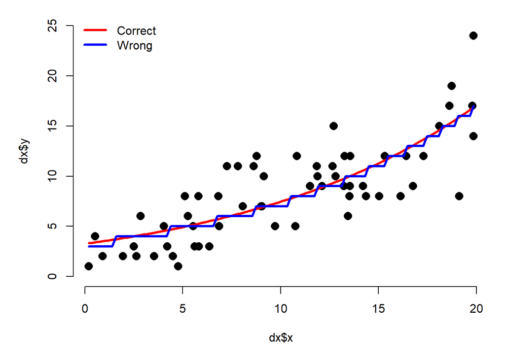

Figure 13: Plot of simulated count data, where $Y$ increases with $X$, with a correctly generated trendline (red, smooth) and an incorrect trendline (blue, stepwise).

```r
# x values
px <- seq(min(dx$x), max(dx$x), length=100)
# data frame
prx <- data.frame(x=px)
# predictions the correct way
pred.correct <- predict(mod8, newdata=prx, se.fit=TRUE, type="link")
prx$mn.correct <- exp(qnorm(0.5, pred.correct$fit, pred.correct$se.fit))
prx$mn.wrong1 <- qpois(0.5, exp(pred.correct$fit))

# predictions the wrong way
# (not plotted)
pred.wrong <- predict(mod8, newdata=prx, type="response")
prx$mn.wrong2 <- qpois(0.5, pred.wrong)

par(mar=c(5.1, 5.1, 1.1, 1.1), bty="n")
plot(dx$x, dx$y, pch=16, cex=1.5, ylim=c(0, 25))
points(prx$x, prx$mn.correct, type="l", lwd=3, col="red")
points(prx$x, prx$mn.wrong1, type="l", lwd=3, col="blue")
legend("topleft", legend=c("Correct", "Wrong"),
       lwd=3, col=c("red", "blue"), bty="n")
```

**Tip**

**Overdispersion**

Sometimes count data can be **overdispersed**, in which case they have more variance than would be expected under a Poisson distribution. In such a case, you can try fitting a **negative binomial GLM**, which has an extra term to account for the excess variance. Negative binomial GLMs are available in package `MASS`.

## 8.2 Models for binary outcomes: Logistic Regression

Sometimes biologists need to model **binary outcomes**: response variables that can take on only one of two values such as alive or dead, presence or absent, or reproduced or did not reproduce. The tool for such variables is **logistic regression**.

The response variable $Y$ takes on value 1 when some event occurs, and 0 otherwise. For example, if you are studying the presence of a rare mushroom species across many forest patches, you would code the sites with the mushroom `1` and the sites without the mushroom `0`. Your analysis would then include a term for the probability of $Y=1$, $p\left(Y=1\right)$. Because probabilities can only occur in the closed interval [0, 1], we cannot use linear models for them because–as with the count data above–the normal distribution part of the linear model can produce nonsensical values.

Logistic regression is defined in observation-wise notation as (subscript $i$ is for observation):

$$Y_i \sim \mathcal{Bernoulli}\left(p_i\right)$$

$$log\left(\frac{p_i}{1-p_i}\right)=\eta_i$$

$$\eta_i=\beta_0+\beta_1X_i$$

The link function $log\left(x/\left(1-x\right)\right)$ is the **logit function**, which maps probabilities in the open interval $\left(0,1\right)$ to the real number line, the domain of the $\eta$. $Logit\left(0.5\right)=0$; as $p$ approaches 1, $logit\left(p\right)$ increases, and vice versa. This lets us use map a linear function to the bounded co-domain of probabilities.

As with the other GLMs, let’s simulate our own dataset and fit the model to it.

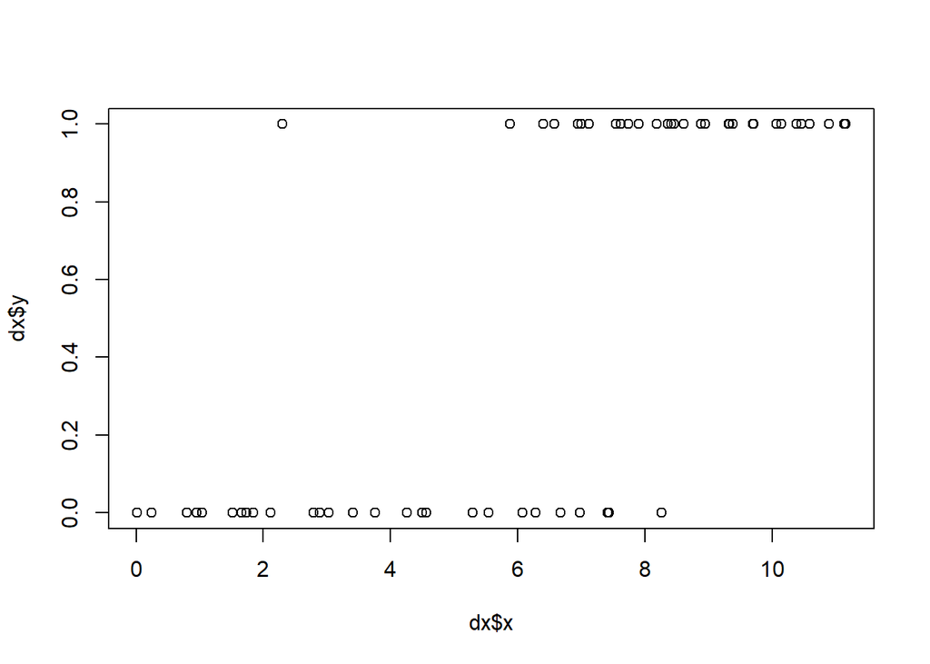

Figure 14: Plot of simulated binary response data, where p(y=1) appears to increase with x.

```r
set.seed(234)
n <- 60
dx <- data.frame(x=runif(n, 0, 12))
beta0 <- -4.3
beta1 <- 0.72
dx$eta <- beta0 + beta1*dx$x
dx$p <- plogis(dx$eta)
dx$y <- rbinom(n, 1, dx$p)

# check the data
plot(dx$x, dx$y, ylim=c(0, 1))
```

We can fit logistic regression model to these data:

```r
mod9 <- glm(y~x, data=dx, family=binomial(link="logit"))

summary(mod9)
```

```
Call:
glm(formula = y ~ x, family = binomial(link = "logit"), data = dx)

Coefficients:
            Estimate Std. Error z value Pr(>|z|)
(Intercept)  -5.9577     1.7244  -3.455 0.000550 ***
x             0.9425     0.2471   3.815 0.000136 ***
---
Signif. codes:  0 '***' 0.001 '**' 0.01 '*' 0.05 '.' 0.1 ' ' 1

(Dispersion parameter for binomial family taken to be 1)

    Null deviance: 82.911  on 59  degrees of freedom
Residual deviance: 38.472  on 58  degrees of freedom
AIC: 42.472

Number of Fisher Scoring iterations: 6
```

The slope estimate for `x`, 0.9425, can be used to calculate the **odds ratio** or effect of `x`. Every unit increase in `x` multiplies the odds of $Y=1$ by $e^{\beta_1}$. In this case, increasing `x` by 1 will multiply the odds of $Y=1$ by $e^{0.9425}=2.71282^{0.9425}=2.5664$. Thus, negative slopes will decrease the likelihood of $Y-1$, while positive slopes will increase it.

**Tip**

**Odds vs. probabilities**

Odds and probabilities are two complementary ways of expressing how likely some event is. Probability is the number of successes per number of *trials*. The odds are the number of successes per number of *failures*. Odds and probability are related. E.g., if a coin comes up heads 2 times out of 8, then $p\left(heads\right)=2/8=0.25$. The odds of heads are $\left(2/8\right)/\left(1-\left(2/8\right)\right)=0.25/0.75=1/3$.

**Odds ratios** are just one more step, expression a change in the probability as the change in odds. Odds ratios are particularly useful when discussing changes in probability near 0 or 1. E.g., changing probability from 0.96 to 0.98 or from 0.52 to 0.54 both have the same change in terms of probability ($+0.02$), but the first change is a much larger change in odds (OR = 2.04 vs. 1.08).

For logistic regression, we can either use pseudo-$R^2$ to measure goodness-of-fit, or we can use a statistic called **AUC** to measure how well the model discriminates between observations where $Y=1$ and those where $Y=0$.

The **receiver operating characteristic (ROC) curve** summarizes the trade-off between sensitivity (true positive rate) and specificity (true negative rate) for a logistic regression model. The area under the ROC curve, or **AUC**, is a value that ranges from about 0.5 (as accurate as a coin flip) to 1 (perfect sensitivity and specificity). It is available in the package `pROC`.

```r
# install if needed
install.packages("pROC")

# load
library(pROC)
```

In order to get the AUC, we need to first get the model predictions and then compare those to the original data.

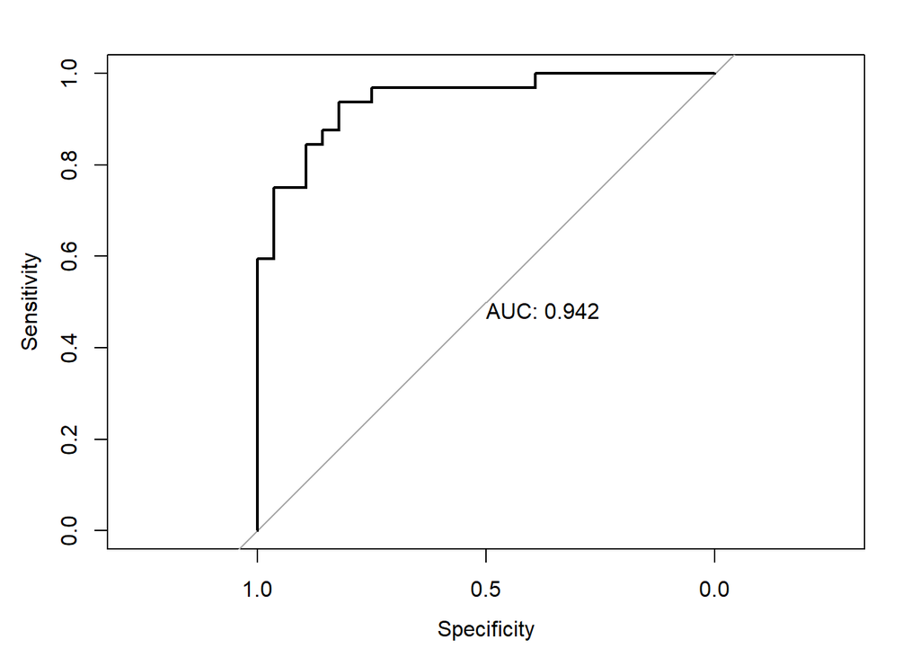

Figure 15: Receiver operating characteristic (ROC) curve for a logistic regression on simulated data. The area under the curve (AUC) is a measure of predictive accuracy.

```r
p9 <- predict(mod9, type="response")
roc9 <- roc(dx$y~p9, plot=TRUE, print.auc=TRUE)
```

The AUC of this model, 0.942, means that the model is very good at distinguishing observations where $Y=1$ from observations where $Y=0$. Many people interpret AUC as a measure of predictive accuracy, but what it really does is measure how well the model orders the probabilities of $Y=1$ for each observation. AUC is the probability that a randomly chosen positive observation will receive a higher score than a randomly chosen negative observation. It does not tell us the absolute probability of a prediction being correct; a model could have high AUC even if its predicted probabilities were poorly calibrated.

The take-home message is that AUC is one useful tool in evaluating the performance of a logistic regression model, but, like $R^2$ for linear models or AIC for models in general, it represents but one perspective among many.

Plotting a trendline for a logistic regression means plotting the data and a line for $p(Y=1)$.

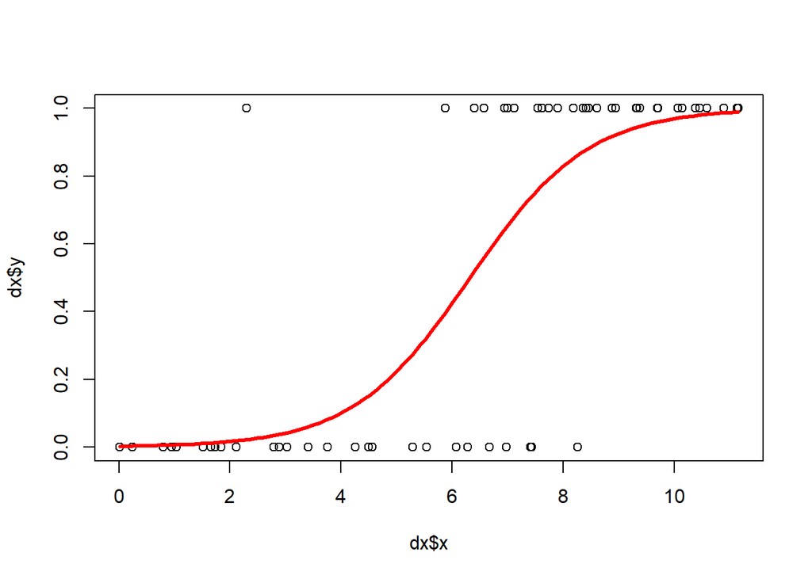

Figure 16: Plot of simulated binary response data, where p(y=1) appears to increase with x, with red trendline predicted by the model.

```r
px <- seq(min(dx$x), max(dx$x), length=100)
prx <- data.frame(x=px)
pred <- predict(mod9, newdata=prx, type="link", se.fit=TRUE)
prx$mn <- plogis(qnorm(0.5, pred$fit, pred$se.fit))

plot(dx$x, dx$y, ylim=c(0, 1))
points(prx$x, prx$mn, type="l", lwd=3, col="red")
```

## 8.3 Models for proportions: Binomial Regression

The last GLM that biologists encounter is **binomial regression**, which analyzes proportions or percentages. This is very close related to logistic regression in that they both use the **binomial distribution**. For a $Y$ variable containing proportions or probabilities in the open interval $\left(0,1\right)$:

$$Y_i=\frac{z_i}{n_i}$$

$$z_i \sim \mathcal{Binomial}\left(n_i,p_i\right)$$

$$log\left(\frac{p_i}{1-p_i}\right)=\beta_0+\beta_1X_i$$

Because binomial and logistic regression are so similar, there is confusion about when to use each. The answer depends on your question:

- If the question is about outcomes at the individual observation level, then use logistic regression.
- If the question is about rates or probabilities of an event occurring, then use binomial regression.

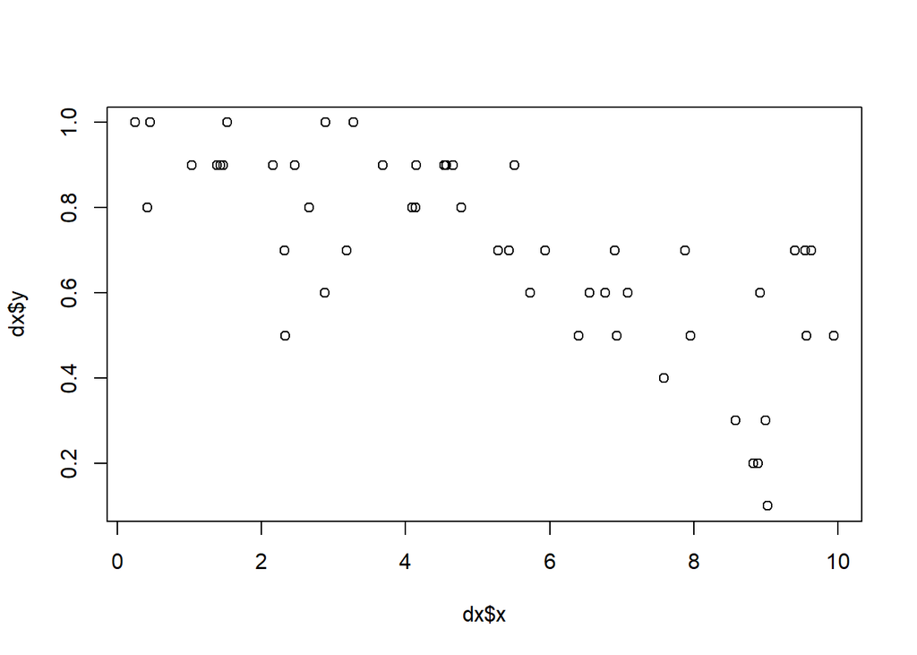

Figure 17: Plot of simulated binomial (proportion) response data, where y decreases as x increases.

```r
set.seed(123)
n <- 50
dx <- data.frame(x=runif(n, 0, 10))
dx$z <- 3 + -0.75*x + rnorm(n, 0, 1)

# inverse logit
dx$y <- round(plogis(dx$z), 1)

# weights = sample sizes
# use same size for each observation for simplicity
dx$wts <- rep(10, n)

# plot of a proportion (y) vs. a predictor (x)
plot(dx$x, dx$y)
```

Now we can fit a binomial GLM with the default logit link. The argument `weights` defines the sample sizes represented by each probability (Y value) converts the model to a binomial regression. For example, an observation with Y = 0.3 and weights = 10 represents a trial or group of observations with 3 successes in 10 trials. You must supply a vector with a weight for each observation. Basically, if Y is a proportion, then `weights` is the denominator of that proportion.

```r
mod10 <- glm(y~x, data=dx, family=binomial, weights=wts)
summary(mod10)
```

```
Call:
glm(formula = y ~ x, family = binomial, data = dx, weights = wts)

Coefficients:
            Estimate Std. Error z value Pr(>|z|)
(Intercept)  2.51773    0.26011   9.679  < 2e-16 ***
x           -0.29588    0.03893  -7.600 2.96e-14 ***
---
Signif. codes:  0 '***' 0.001 '**' 0.01 '*' 0.05 '.' 0.1 ' ' 1

(Dispersion parameter for binomial family taken to be 1)

    Null deviance: 133.965  on 49  degrees of freedom
Residual deviance:  66.704  on 48  degrees of freedom
AIC: 180.02

Number of Fisher Scoring iterations: 4
```

Like Poisson regression, we can evaluate the model using the pseudo-$R^2$ and compare models using the AIC.

```r
1-mod10$deviance/mod10$null.deviance
```

```
[1] 0.5020788
```

## 8.4 Gamma GLMs for overdispersed continuous data

# 9 Tests for contingency

Sometimes biological data do not come with neatly-defined numeric responses. Often, the response “variable” is whether or not an observation belongs to a particular category or not—or a combination of categories. These can be called **categorical data**, where the information of interest is not a numeric value, but identity or classification. Consider the (made up) data from a pesticide exposure experiment below:

Table 1: Pollen production by pesticide treatment.

| Pollen production | Unexposed | Exposed |
| --- | --- | --- |
| None | 17 | 6 |
| Reduced | 3 | 4 |
| Normal | 4 | 14 |

This table tallies the fates of 48 plants that were *exposed* or *not exposed* to an experimental pesticide. The outcomes were classified as *no pollen production*, *reduced pollen production*, and *normal pollen production*. Rather than asking a question about the mean pollen production in each group, the researchers might ask whether the fate of a plant (in terms of pollen production) is independent of whether or not it was treated. This is known as a **test of independence**.

A good clue for whether or not you need to do a test for independence is whether or not your data are best summarized in a contingency table such as the table above. A contingency table shows how often observations fall into each category within a dataset.

## 9.1 Fisher’s exact test

**Fisher’s exact test** is a test for independence in contingency tables that is usually only used when sample sizes are small or when the $\chi^2$ test gives questionable approximations.

```r
# make an R version of the matrix above
# make a matrix from the table above
a <- matrix(c(17,6,3,4,4,14), byrow=TRUE, nrow=3)
a
```

```
     [,1] [,2]
[1,]   17    6
[2,]    3    4
[3,]    4   14
```

And now the test:

```r
fisher.test(a)
```

```
    Fisher's Exact Test for Count Data

data:  a
p-value = 0.002849
alternative hypothesis: two.sided
```

Because Fisher’s is an exact test (i.e., the *p*-value is an direct, exact calculation), there is no test statistic and no degrees of freedom to report.

## 9.2 Chi-squared test

The chi-square ($\chi^2$) test is a more powerful, flexible, and computationally efficient cousin of the Fisher’s exact test. It works by comparing the input contingency table to what the contingency table would be expected to look like under the assumption of independence. That is, if the null hypothesis were true. The test statistic, $\chi^2$, measures how different the two contingency tables are. The test works better with large sample sizes; with small sample sizes, the approximations use to estimate the *p*-value can break down. A good rule of thumb is that every cell (or most cells) of the hypothetical null contingency table should have $\geq5$ observations.

```r
# make a matrix from the table above
a <- matrix(c(17,6,3,4,4,14), byrow=TRUE, nrow=3)

# run the test
chisq.test(a)
```

```
    Pearson's Chi-squared test

data:  a
X-squared = 10.959, df = 2, p-value = 0.004171
```

One advantage of the $\chi^2$ test in R vs. the Fisher’s test is that it returns the expected contingency table, for comparison. This can help you see which categories are the most over- or underrepresented.

```r
cq1 <- chisq.test(a)
```

[output not shown]

```r
cq1$expected
```

```
     [,1] [,2]
[1,] 11.5 11.5
[2,]  3.5  3.5
[3,]  9.0  9.0
```

This helps us see that the apparent lack of independence is likely driven by the relative numbers of “none” and “normal” pollen producers.